# Praca domowa 5

Jakub Bondyra

November 19, 2017

W ostatnim czasie na portalu angielskojęzycznego, mongolskiego czasopisma *UB Post* pojawił się artykuł dotyczący stanu powietrza w Mongolii (artykuł dostępny pod adresem http://theubpost.mn/2017/10/18/air-quality-labeled-unhealthy-at-tolgoit-mnb-and-amgalan/).

Dodatkowo, w danych pojawia się nazwa jeszcze jednej stacji - Bayankhoshuu. Nazwa tej stacji oznacza prawdopodobnie port znajdujący się w dalekiej, zachodniej części kraju. Nie jestem tego jednakże pewien, co jest dość fascynujące - naprawdę ciężko znaleźć sensowne informacje na temat tego kraju.

W celu ułatwienia interpretacji wyników, poniżej zamieszczam mapę Ułan Bator z zaznaczonymi stacjami pomiarowymi.

[figure not shown]

Tabela jest wypełniona suchymi wartościami, zatem uznałem, że dobrze byłoby zwizualizować w przystępny sposób te wartości za pomocą prostego wykresu. Zastosowany jest w nim stosunek wartości stężenia substancji w danym miejscu do normy stężenia przyjętej w Mongolii - zatem jest to taka wartość procentowa, do której przywykliśmy czytając informacje w Polsce.

Nie widzę sensu uwzględniania w wizualizacji poziomów wszystkich wymienianych substancji, dlatego też uwzględniam cztery najważniejsze - $PM_{2.5}$, $PM_{10}$, $SO_2$ i $NO_2$. Szarym kolorem oznaczane są wartości brakujące.

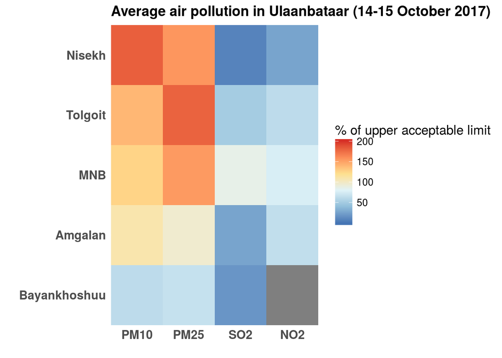

```r
library(ggplot2)
a = read.table("mongolia.txt",header=T,sep="\t")
norms = c(100,50,50,50)

library(reshape2)

a2 = a
a2$Location = factor(a$Location,levels = a$Location[c(5,3,2,1,4)])
a2$PM10 = a2$PM10
a2$PM25 = a2$PM25*2
a2$SO2 = a2$SO2*2
a2$NO2 = a2$NO2*2
am = melt(a2)

ggplot(data=am, aes(variable, Location)) + geom_tile(aes(fill=value)) +
  scale_fill_distiller(palette="RdYlBu",direction=-1,name="% of upper acceptable limit",
                       breaks=c(50,100,150,200),lim=c(0,200))+
  scale_x_discrete(expand=c(0,0))+
  scale_y_discrete(expand=c(0,0))+
  ggtitle("Average air pollution in Ulaanbataar (14-15 October 2017)")+
  xlab("") + ylab("")+
      theme(legend.title = element_text(size=13),
        legend.text=element_text(size=10),
        plot.title = element_text(size=14,face="bold"),
        axis.text.x=element_text(size=12, face="bold"),
        axis.ticks.x=element_blank(),
       axis.text.y=element_text(size=12, face="bold"),
        axis.ticks.y=element_blank())
```